# *EDA ON PNEUMONIA DATASET*

### **1. IMPORTING NECESSARY LIBRARIES**

```python
# Working with data
import numpy as np                  # To Perform Mathematical Operations and Linear Algebra
import pandas as pd                 # To Perform Operations on Dataframes

# Visualization
import matplotlib.pyplot as plt     # To Plot Maps and Graphs
import seaborn as sns               # Helps in Advanced Visualization of Plots and Graphs
sns.set_style('darkgrid')           # To Add Nice Background to Plots and Graphs
%matplotlib inline
                                    # To Tell Python to Display the Graphs

#Handling warning messages
import warnings
warnings.filterwarnings('ignore')   # To ignore warnings
```

### **2. LOADING THE DATASET**

```python
data = pd.read_csv('EDA.csv')            #Loading the dataframe and saving as 'data'
data.head()                              #Displays the first five rows of the Dataframe (with index values 0 to 4)
```

|  | patientId | x | y | width | height | Target | class | PatientAge | PatientSex | ViewPosition |
| --- | --- | --- | --- | --- | --- | --- | --- | --- | --- | --- |
| 0 | 0004cfab-14fd-4e49-80ba-63a80b6bddd6 | 0.0 | 0.0 | 0.0 | 0.0 | 0 | No Lung Opacity / Not Normal | 51 | F | PA |
| 1 | 00313ee0-9eaa-42f4-b0ab-c148ed3241cd | 0.0 | 0.0 | 0.0 | 0.0 | 0 | No Lung Opacity / Not Normal | 48 | F | PA |
| 2 | 00322d4d-1c29-4943-afc9-b6754be640eb | 0.0 | 0.0 | 0.0 | 0.0 | 0 | No Lung Opacity / Not Normal | 19 | M | AP |
| 3 | 003d8fa0-6bf1-40ed-b54c-ac657f8495c5 | 0.0 | 0.0 | 0.0 | 0.0 | 0 | Normal | 28 | M | PA |
| 4 | 00436515-870c-4b36-a041-de91049b9ab4 | 264.0 | 152.0 | 213.0 | 379.0 | 1 | Lung Opacity | 32 | F | AP |

```python
data.tail()          #Displays the last five rows of the Dataframe [with index values (n-4) to n]
```

|  | patientId | x | y | width | height | Target | class | PatientAge | PatientSex | ViewPosition |
| --- | --- | --- | --- | --- | --- | --- | --- | --- | --- | --- |
| 30222 | c1ec14ff-f6d7-4b38-b0cb-fe07041cbdc8 | 185.0 | 298.0 | 228.0 | 379.0 | 1 | Lung Opacity | 54 | M | AP |
| 30223 | c1edf42b-5958-47ff-a1e7-4f23d99583ba | 0.0 | 0.0 | 0.0 | 0.0 | 0 | Normal | 46 | F | PA |
| 30224 | c1f6b555-2eb1-4231-98f6-50a963976431 | 0.0 | 0.0 | 0.0 | 0.0 | 0 | Normal | 45 | M | PA |
| 30225 | c1f7889a-9ea9-4acb-b64c-b737c929599a | 570.0 | 393.0 | 261.0 | 345.0 | 1 | Lung Opacity | 72 | F | AP |
| 30226 | c1f7889a-9ea9-4acb-b64c-b737c929599a | 233.0 | 424.0 | 201.0 | 356.0 | 1 | Lung Opacity | 72 | F | AP |

```python
data.shape     # Returns the number of rows and columns in the dataset.
```

```
(30227, 10)
```

```python
data.columns    # Specifies the column names in the dataset
```

```
Index(['patientId', 'x', 'y', 'width', 'height', 'Target', 'class',
       'PatientAge', 'PatientSex', 'ViewPosition'],
      dtype='object')
```

#### *OBSERVATIONS:* Our dataset contains 30227 rows and 10 columns (Namely 'patient ID', 'x', 'y', 'width', 'height', 'Target', 'class', 'PatientAge', 'PatientSex', and 'ViewPosition')

### **3. ATTRIBUTE INFORMATION**

```python
data.info()          # Gives information about the number and type of each attribute in the dataset.
```

```
<class 'pandas.core.frame.DataFrame'>
RangeIndex: 30227 entries, 0 to 30226
Data columns (total 10 columns):
 #   Column        Non-Null Count  Dtype
---  ------        --------------  -----
 0   patientId     30227 non-null  object
 1   x             30227 non-null  float64
 2   y             30227 non-null  float64
 3   width         30227 non-null  float64
 4   height        30227 non-null  float64
 5   Target        30227 non-null  int64
 6   class         30227 non-null  object
 7   PatientAge    30227 non-null  int64
 8   PatientSex    30227 non-null  object
 9   ViewPosition  30227 non-null  object
dtypes: float64(4), int64(2), object(4)
memory usage: 2.3+ MB
```

```python
list = []
for col in data.columns:
    list.append([col, data[col].dtypes, data[col].isna().sum(), data[col].nunique(), data[col].unique()])
description = pd.DataFrame(columns = ['Attribute', 'Attribute Type', 'Null Value Count', 'Unique Count', 'Unique Items'], data=list)
description
```

|  | Attribute | Attribute Type | Null Value Count | Unique Count | Unique Items |
| --- | --- | --- | --- | --- | --- |
| 0 | patientId | object | 0 | 26684 | [0004cfab-14fd-4e49-80ba-63a80b6bddd6, 00313ee... |
| 1 | x | float64 | 0 | 749 | [0.0, 264.0, 562.0, 323.0, 695.0, 288.0, 547.0... |
| 2 | y | float64 | 0 | 727 | [0.0, 152.0, 577.0, 575.0, 322.0, 299.0, 544.0... |
| 3 | width | float64 | 0 | 352 | [0.0, 213.0, 256.0, 160.0, 162.0, 94.0, 119.0,... |
| 4 | height | float64 | 0 | 726 | [0.0, 379.0, 453.0, 104.0, 137.0, 135.0, 165.0... |
| 5 | Target | int64 | 0 | 2 | [0, 1] |
| 6 | class | object | 0 | 3 | [No Lung Opacity / Not Normal, Normal, Lung Op... |
| 7 | PatientAge | int64 | 0 | 97 | [51, 48, 19, 28, 32, 54, 78, 75, 59, 63, 6, 23... |
| 8 | PatientSex | object | 0 | 2 | [F, M] |
| 9 | ViewPosition | object | 0 | 2 | [PA, AP] |

#### *OBSERVATIONS:* **This operation gives us the following information:**

#### *A. NUMBER AND TYPE OF VARIABLES PRESENT IN THE DATASET:*

#### Our dataset contains 10 Variables (2 INTEGER TYPE, 4 FLOAT TYPE, AND 4 OBJECT TYPE)

#### *B. INDEPENDENT AND DEPENDENT (TARGET VARIABLES):*

#### Looking at the problem statement of this project which requires us to predict whether the patient has Pneumonia or not by looking at the the corresponding X-ray Scan, 'Target' or 'class' is our DEPENDENT OR TARGET VARIABLE, whereas ALL OTHER VARIABLES are INDEPENDENT ATTRIBUTES.

#### *C. PRESENCE OF MISSING VALUES:*

#### Out of the 10 features or attributes, none of them containing any missing values.

#### *D. UNIQUE VALUES AND UNIQUE VALUE COUNTS:*

#### We can clearly see the number and types of unique values for each attribute of our dataframe.

### **4. MAKING A COPY OF ORIGINAL DATASET**

```python
data1 = data.copy()          #Copies the dataset and stores the name of the copy as 'df'
data1.shape
```

```
(30227, 10)
```

#### *OBSERVATIONS:* We have now created a copy of the original dataset and checked that it contains the same number of rows and columns as the original one. We shall use this copy to analyse and carry out all the operations.

### **5. CHECKING DUPLICATE ENTRIES**

#### We shall be checking the presence of any duplicate entries in our dataset by using the following code:

```python
data1.duplicated().sum()          #Checks presence of duplicate entries in the dataset.
```

```
0
```

#### *OBSERVATIONS:* Our dataset contains no rows with duplicate entries.

### **6. 5-POINT SUMMARY OF THE DATASET ATTRIBUTES**

```python
data1.describe(include='all').T
```

|  | count | unique | top | freq | mean | std | min | 25% | 50% | 75% | max |
| --- | --- | --- | --- | --- | --- | --- | --- | --- | --- | --- | --- |
| patientId | 30227 | 26684 | 31764d54-ea3b-434f-bae2-8c579ed13799 | 4 | NaN | NaN | NaN | NaN | NaN | NaN | NaN |
| x | 30227.0 | NaN | NaN | NaN | 124.561683 | 216.326397 | 0.0 | 0.0 | 0.0 | 193.0 | 835.0 |
| y | 30227.0 | NaN | NaN | NaN | 115.960962 | 190.012883 | 0.0 | 0.0 | 0.0 | 231.0 | 881.0 |
| width | 30227.0 | NaN | NaN | NaN | 69.060575 | 106.910496 | 0.0 | 0.0 | 0.0 | 169.0 | 528.0 |
| height | 30227.0 | NaN | NaN | NaN | 104.084825 | 176.932152 | 0.0 | 0.0 | 0.0 | 188.0 | 942.0 |
| Target | 30227.0 | NaN | NaN | NaN | 0.316108 | 0.464963 | 0.0 | 0.0 | 0.0 | 1.0 | 1.0 |
| class | 30227 | 3 | No Lung Opacity / Not Normal | 11821 | NaN | NaN | NaN | NaN | NaN | NaN | NaN |
| PatientAge | 30227.0 | NaN | NaN | NaN | 46.797764 | 16.89294 | 1.0 | 34.0 | 49.0 | 59.0 | 155.0 |
| PatientSex | 30227 | 2 | M | 17216 | NaN | NaN | NaN | NaN | NaN | NaN | NaN |
| ViewPosition | 30227 | 2 | AP | 15297 | NaN | NaN | NaN | NaN | NaN | NaN | NaN |

#### This operation provides us a 5-point summary of the attributes with their value counts, mean, standard deviation, min-max values and Q1, Q2 and Q3 values. We shall analyze this summary for each attribute during the corresponding univariate analysis.

### **7. UNIVARIATE ANALYSIS**

#### We shall now examine each attribute one by one and draw inferences accordingly as follows:

### *7.1. 'PATIENT ID' COLUMN*

```python
# Checking total number of instances in Patient Id Column
len(data1['patientId'])
```

```
30227
```

#### This operation shows that total number of Patient IDs is 30227.

#### But preliminary analysis hints at the fact that actually there are lesser number of patients than 30227.

#### Let's check the number of unique patient id's which will be equal to the total number of patients examined.

```python
#Checking number of unique patient id's (equal to number of patients examined)
data1['patientId'].nunique()
```

```
26684
```

#### This is because some positive pneumonia patients have more than 1 bounding boxes.

#### Let's group by patient IDs and check number of bounding boxes for each unique patient id

```python
bboxes = data1.groupby('patientId').size().to_frame('number_of_boxes').reset_index()
data1 = data1.merge(bboxes, on = 'patientId', how = 'left')
print('Number of unique patient IDs in the dataset: {}'.format(len(bboxes)))
print('\nNumber of patient IDs per bounding boxes in the dataset')
(bboxes.groupby('number_of_boxes')
.size()
.to_frame('No. of Patient IDs per box')
.reset_index()
.set_index('number_of_boxes')
.sort_values(by = 'number_of_boxes'))
```

```
Number of unique patient IDs in the dataset: 26684

Number of patient IDs per bounding boxes in the dataset
```

| number_of_boxes | No. of Patient IDs per box |
| --- | --- |
| 1 | 23286 |
| 2 | 3266 |
| 3 | 119 |
| 4 | 13 |

#### This operation gives us the distribution of Patient IDs in terms of number of bounding boxes. But the number of instances with bounding box class 1 also contain all those Patient ID's which are Normal.

#### We shall try to bifurcate this figure in the following step.

```python
data1[data1['Target'] == 0]['patientId'].value_counts().value_counts()
```

```
1    20672
Name: patientId, dtype: int64
```

```python
data1[data1['Target'] == 1]['patientId'].value_counts().value_counts()
```

```
2    3266
1    2614
3     119
4      13
Name: patientId, dtype: int64
```

#### *OBSERVATIONS:* We are now able to see that the distribution of Patient IDs is as follows:

- Normal Cases : 20,672
- 1 Bounding Box : 2,614
- 2 Bounding Boxes : 3,266
- 3 Bounding Boxes : 119
- 4 Bounding Boxes : 13
- Total Cases : 26,684

#### Based on these observations we shall create a new dataset 'df' containing only patients with unique id's

```python
df = data1.drop_duplicates(subset = 'patientId')
df
```

|  | patientId | x | y | width | height | Target | class | PatientAge | PatientSex | ViewPosition | number_of_boxes |
| --- | --- | --- | --- | --- | --- | --- | --- | --- | --- | --- | --- |
| 0 | 0004cfab-14fd-4e49-80ba-63a80b6bddd6 | 0.0 | 0.0 | 0.0 | 0.0 | 0 | No Lung Opacity / Not Normal | 51 | F | PA | 1 |
| 1 | 00313ee0-9eaa-42f4-b0ab-c148ed3241cd | 0.0 | 0.0 | 0.0 | 0.0 | 0 | No Lung Opacity / Not Normal | 48 | F | PA | 1 |
| 2 | 00322d4d-1c29-4943-afc9-b6754be640eb | 0.0 | 0.0 | 0.0 | 0.0 | 0 | No Lung Opacity / Not Normal | 19 | M | AP | 1 |
| 3 | 003d8fa0-6bf1-40ed-b54c-ac657f8495c5 | 0.0 | 0.0 | 0.0 | 0.0 | 0 | Normal | 28 | M | PA | 1 |
| 4 | 00436515-870c-4b36-a041-de91049b9ab4 | 264.0 | 152.0 | 213.0 | 379.0 | 1 | Lung Opacity | 32 | F | AP | 2 |
| ... | ... | ... | ... | ... | ... | ... | ... | ... | ... | ... | ... |
| 30219 | c1e73a4e-7afe-4ec5-8af6-ce8315d7a2f2 | 666.0 | 418.0 | 186.0 | 223.0 | 1 | Lung Opacity | 47 | F | AP | 2 |
| 30221 | c1ec14ff-f6d7-4b38-b0cb-fe07041cbdc8 | 609.0 | 464.0 | 240.0 | 284.0 | 1 | Lung Opacity | 54 | M | AP | 2 |
| 30223 | c1edf42b-5958-47ff-a1e7-4f23d99583ba | 0.0 | 0.0 | 0.0 | 0.0 | 0 | Normal | 46 | F | PA | 1 |
| 30224 | c1f6b555-2eb1-4231-98f6-50a963976431 | 0.0 | 0.0 | 0.0 | 0.0 | 0 | Normal | 45 | M | PA | 1 |
| 30225 | c1f7889a-9ea9-4acb-b64c-b737c929599a | 570.0 | 393.0 | 261.0 | 345.0 | 1 | Lung Opacity | 72 | F | AP | 2 |

26684 rows × 11 columns

```python
df.shape
```

```
(26684, 11)
```

#### *OBSERVATIONS:* Our freshly created dataset 'df' contains 26,684 unique patient instances and will be used for all EDA from now on.

### *7.2. 'PATIENT AGE' COLUMN*

```
The minimum value in 'PatientAge' column is 1
The maximum value in 'PatientAge' column is 155
The range of values in 'PatientAge' column is 154
The mean of values in 'PatientAge' column is 47.03
The median of values in 'PatientAge' column is 49.0
The standard deviation of 'PatientAge' column is 16.81
The 1st Quantile (25%) value for 'PatientAge' column is 34.0
The 2nd Quantile (50%) value for 'PatientAge' column is 49.0
The 3rd Quantile (75%) value for 'PatientAge' column is 59.0
The Inter Quantile Range (IQR) for 'PatientAge' column is 25.0
Note: All the above values are in years
The skewness of 'PatientAge' distribution is -0.25
```

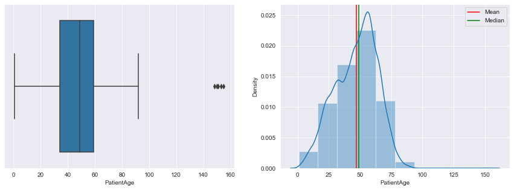

```python
print("The minimum value in 'PatientAge' column is", df.PatientAge.min())
print("The maximum value in 'PatientAge' column is", df.PatientAge.max())
print("The range of values in 'PatientAge' column is", df.PatientAge.max()-df.PatientAge.min())
age_mean = round(df.PatientAge.mean(), 2)
print("The mean of values in 'PatientAge' column is", age_mean)
age_med = round(df.PatientAge.median(), 2)
print("The median of values in 'PatientAge' column is", age_med)
print("The standard deviation of 'PatientAge' column is", round(df.PatientAge.std(), 2))
age_q1 = round(df.PatientAge.quantile(0.25), 2)
age_q2 = round(df.PatientAge.quantile(0.50), 2)
age_q3 = round(df.PatientAge.quantile(0.75), 2)
age_iqr = age_q3 - age_q1
print("The 1st Quantile (25%) value for 'PatientAge' column is", age_q1)
print("The 2nd Quantile (50%) value for 'PatientAge' column is", age_q2)
print("The 3rd Quantile (75%) value for 'PatientAge' column is", age_q3)
print("The Inter Quantile Range (IQR) for 'PatientAge' column is", age_iqr)
print("Note: All the above values are in years")
print("The skewness of 'PatientAge' distribution is", round(df.PatientAge.skew(), 2))
fig, axes = plt.subplots(1, 2, figsize=(15, 5))
sns.boxplot(df['PatientAge'], ax=axes[0])
plt.axvline(age_mean, color = 'r')
plt.axvline(age_med, color = 'g')
sns.distplot(df['PatientAge'],ax=axes[1], bins=10)
plt.legend(['Mean', 'Median'])
```

#### The boxplot indicates the presence of some outlier age values above 100 years which seems unrealistic.

#### Let's check these values.

```python
df[df['PatientAge']>=100]['PatientAge'].value_counts()
```

```
153    1
155    1
148    1
150    1
151    1
Name: PatientAge, dtype: int64
```

#### Here we observed that there are exactly 5 patient id's with age ranges between 148-155 years. This seems to be a result of some error while data preparation and needs to be treated before feeding into the model.

#### Let's check the overall distribution of Patient Age as compared to that of Pneumonic Patients

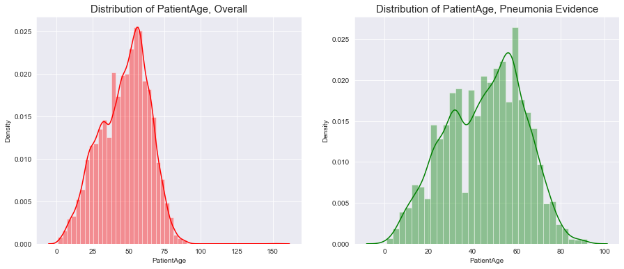

```python
fig = plt.figure(figsize = (15, 6))
ax = fig.add_subplot(121)
g = (sns.distplot(df['PatientAge'], color = 'red')
    .set_title('Distribution of PatientAge, Overall', fontsize = 15))
ax = fig.add_subplot(122)
g = (sns.distplot(df.loc[df['Target'] == 1, 'PatientAge'], color = 'green')
    .set_title('Distribution of PatientAge, Pneumonia Evidence', fontsize = 15))
```

### *7.3. 'PATIENT SEX' COLUMN*

#### Let's see the gender wise distribution of patients in our dataset

```python
df['PatientSex'].value_counts()
```

```
M    15166
F    11518
Name: PatientSex, dtype: int64
```

#### We can also observe the same graphically with the help of a countplot.

#### Let's also check the distribution of age for those with Pneumonia Evidence, by Gender & Count Plot of Gender

|  | % Gender, Overall | % Gender, Target=1 |
| --- | --- | --- |
| F | 0.43 | 0.42 |
| M | 0.57 | 0.58 |

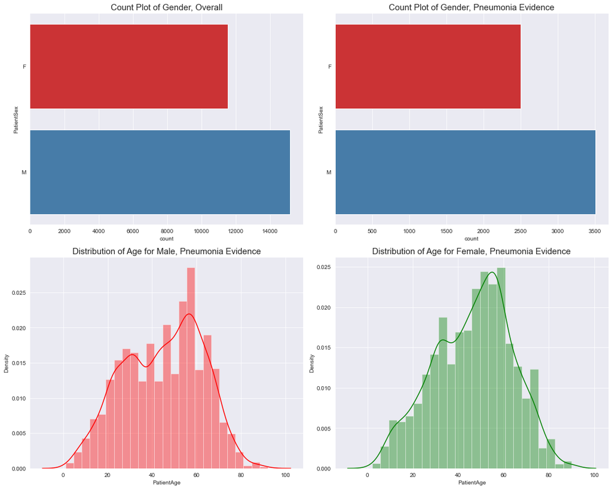

```python
display(pd.concat([df['PatientSex'].value_counts(normalize = True).round(2).sort_values().rename('% Gender, Overall'),
                   df.loc[(df['Target'] == 1), 'PatientSex']
                   .value_counts(normalize = True).round(2).sort_index().rename('% Gender, Target=1')], axis = 1))

f, ((ax1, ax2), (ax3, ax4)) = plt.subplots(2, 2, figsize = (15, 12))
g = sns.distplot(df.loc[(df['Target'] == 1) & (df['PatientSex'] == 'M'), 'PatientAge'], ax = ax3, color = 'red').set_title('Distribution of Age for Male, Pneumonia Evidence', fontsize = 15)
g = sns.distplot(df.loc[(df['Target'] == 1) & (df['PatientSex'] == 'F'), 'PatientAge'], ax = ax4, color = 'green').set_title('Distribution of Age for Female, Pneumonia Evidence', fontsize = 15)
g = sns.countplot(y = df['PatientSex'], ax = ax1, palette = 'Set1').set_title('Count Plot of Gender, Overall', fontsize = 15)
g = sns.countplot(y = df.loc[(df['Target'] == 1), 'PatientSex'], ax = ax2, palette = 'Set1').set_title('Count Plot of Gender, Pneumonia Evidence', fontsize = 15)
plt.tight_layout()
```

### *7.4. 'TARGET' COLUMN*

#### Let's see the distribution of Target Column in the dataset.

```python
df['Target'].value_counts()
```

```
0    20672
1     6012
Name: Target, dtype: int64
```

#### Let's also check this arrangement in graphical manner.

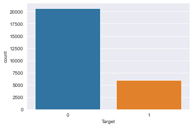

```python
sns.countplot(df['Target']);
```

#### **OBSERVATIONS:** We observed that there are 20,672 patients with Target=0, and 6,012 patients with Target=1.

### *7.5. 'CLASS' COLUMN*

#### Let's analyse the distribution of 'Class' Column.

```python
#Checking the number and names of classes
print("Number of classes in the dataset: %i" %  len(df["class"].unique()))
print("Classes' names are: %s" % df["class"].unique())
```

```
Number of classes in the dataset: 3
Classes' names are: ['No Lung Opacity / Not Normal' 'Normal' 'Lung Opacity']
```

```python
#Checking the number and percentage of instances in each class

def get_feature_distribution(data, feature):
    # Get the count for each label
    label_counts = df[feature].value_counts()

    # Get total number of samples
    total_samples = len(df)

    # Count the number of items in each class
    print("Feature: {}".format(feature))
    for i in range(len(label_counts)):
        label = label_counts.index[i]
        count = label_counts.values[i]
        percent = int((count / total_samples) * 10000) / 100
        print("{:<30s}:   {} or {}%".format(label, count, percent))

get_feature_distribution(df, 'class')
```

```
Feature: class
No Lung Opacity / Not Normal  :   11821 or 44.29%
Normal                        :   8851 or 33.16%
Lung Opacity                  :   6012 or 22.53%
```

#### Let's observe the class distribution graphically.

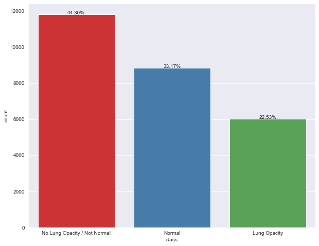

```python
f, ax = plt.subplots(1,1, figsize=(10,8))
total = float(len(df))
sns.countplot(df['class'],order = df['class'].value_counts().index, palette='Set1')
for p in ax.patches:
    height = p.get_height()
    ax.text(p.get_x()+p.get_width()/2.,
            height + 3,
            '{:1.2f}%'.format(100*height/total),
            ha="center")
```

#### **OBSERVATIONS:** As we can see, there are 44% instances of No Lung Opacity / Not Normal, 33% Normal and 22% with Lung Opacity.

### *7.6. 'VIEW POSITION' COLUMN*

#### Let's check how many scans were taken in Anterior Posterior (AP) and Posterior Anterior (PA) Positions

```python
df['ViewPosition'].value_counts()
```

```
PA    14511
AP    12173
Name: ViewPosition, dtype: int64
```

#### Let's also check this arrangement in graphical manner.

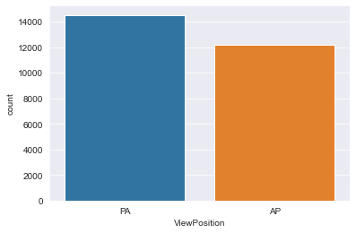

```python
sns.countplot(df['ViewPosition']);
```

```
Get the distribution of `ViewPosition` overall and where Target = 1
Overall the distribution is almost equal for `ViewPosition` but where there's a Pneumonia Evidence, `ViewPosition` is `AP`
AP: Anterior/Posterior, PA: Posterior/Anterior
```

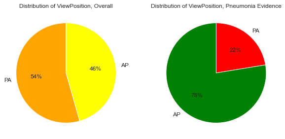

```python
print('Get the distribution of `ViewPosition` overall and where Target = 1')
print('Overall the distribution is almost equal for `ViewPosition` but where there\'s a Pneumonia Evidence, `ViewPosition` is `AP`')
print('AP: Anterior/Posterior, PA: Posterior/Anterior')
fig = plt.figure(figsize = (10, 6))
ax = fig.add_subplot(121)
g = (df['ViewPosition'].value_counts()
    .plot(kind = 'pie', autopct = '%.0f%%',
          colors = ['orange', 'yellow'],
          startangle = 90,
          title = 'Distribution of ViewPosition, Overall',
          fontsize = 12)
    .set_ylabel(''))
ax = fig.add_subplot(122)
g = (df.loc[df['Target'] == 1, 'ViewPosition']
     .value_counts().sort_index(ascending = False)
    .plot(kind = 'pie', autopct = '%.0f%%',
          colors = ['red', 'green'],
          startangle = 90, counterclock = False,
          title = 'Distribution of ViewPosition, Pneumonia Evidence',
          fontsize = 12)
    .set_ylabel(''))
```

#### **OBSERVATIONS:** The above plot shows that there is almost equal distribution of PA and AP View Positions. However for Pneumonia Evidence, AP Position gives significantly more positive results than PA Position.

### *7.7. 'SPATIAL FEATURES: x, y, width, height COLUMNS*

#### As we know the bounding boxes are only present in scans of patients having pneumonia, we will create a sub dataset 'df1' with only Target Class = 1

```python
df1 = data1[data1['Target'] == 1]
df1.head()
```

|  | patientId | x | y | width | height | Target | class | PatientAge | PatientSex | ViewPosition | number_of_boxes |
| --- | --- | --- | --- | --- | --- | --- | --- | --- | --- | --- | --- |
| 4 | 00436515-870c-4b36-a041-de91049b9ab4 | 264.0 | 152.0 | 213.0 | 379.0 | 1 | Lung Opacity | 32 | F | AP | 2 |
| 5 | 00436515-870c-4b36-a041-de91049b9ab4 | 562.0 | 152.0 | 256.0 | 453.0 | 1 | Lung Opacity | 32 | F | AP | 2 |
| 8 | 00704310-78a8-4b38-8475-49f4573b2dbb | 323.0 | 577.0 | 160.0 | 104.0 | 1 | Lung Opacity | 75 | M | PA | 2 |
| 9 | 00704310-78a8-4b38-8475-49f4573b2dbb | 695.0 | 575.0 | 162.0 | 137.0 | 1 | Lung Opacity | 75 | M | PA | 2 |
| 14 | 00aecb01-a116-45a2-956c-08d2fa55433f | 288.0 | 322.0 | 94.0 | 135.0 | 1 | Lung Opacity | 6 | F | AP | 2 |

```python
df1.shape
```

```
(9555, 11)
```

#### This dataset contains 9,555 instances of pneumonia positive patients. Let's check the distribution of spatial features in this dataset.

#### Let's check and analyze the distribution of Bounding Box parameters, namely x & y coordinates, alongwith their widths and heights.

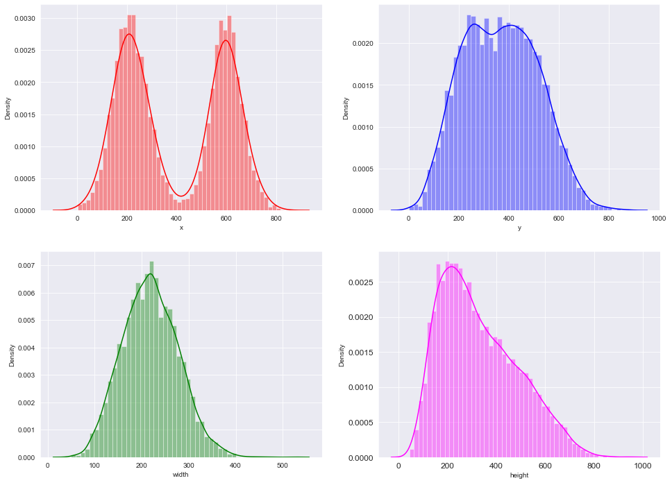

```python
fig, ax = plt.subplots(2,2,figsize=(16,12))
sns.distplot(df1['x'],kde=True,bins=50, color="red", ax=ax[0,0])
sns.distplot(df1['y'],kde=True,bins=50, color="blue", ax=ax[0,1])
sns.distplot(df1['width'],kde=True,bins=50, color="green", ax=ax[1,0])
sns.distplot(df1['height'],kde=True,bins=50, color="magenta", ax=ax[1,1])
locs, labels = plt.xticks()
plt.tick_params(axis='both', which='major', labelsize=12)
```

#### Let's check the boxplots of these attributes

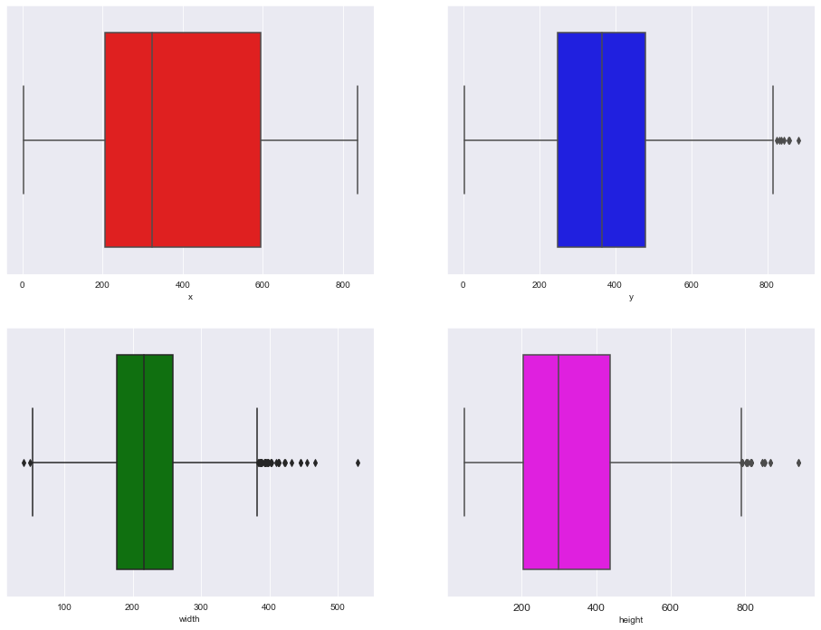

```python
fig, ax = plt.subplots(2,2,figsize=(16,12))
sns.boxplot(df1['x'], color="red", ax=ax[0,0])
sns.boxplot(df1['y'], color="blue", ax=ax[0,1])
sns.boxplot(df1['width'], color="green", ax=ax[1,0])
sns.boxplot(df1['height'], color="magenta", ax=ax[1,1])
locs, labels = plt.xticks()
plt.tick_params(axis='both', which='major', labelsize=12)
```

#### **OBSERVATIONS:**

- The distribution plots hint at near normal distributions of bounding box attributes.
- The distribution plot of x shows 2 gaussians, hinting at 2 different clusters pertaining to each lung.
- Boxplots of y, width and height show some outliers mostly on the upper side of the right whisker.

### **8. BIVARIATE AND MULTIVARIATE ANALYSIS**

#### We shall now examine relationships between different attributes and draw inferences accordingly as follows:

#### Before we go ahead with correlation studies, we must convert the categorical variables into numeric using the following operation.

```python
cleanup_nums = {"class":     {"Normal" : 0, "No Lung Opacity / Not Normal": 1, "Lung Opacity": 2},
                "PatientSex": {"F": 0, "M": 1},
                "ViewPosition": {"PA": 0, "AP": 1}}
```

```python
obj_df = df.replace(cleanup_nums)
obj_df.head()
```

|  | patientId | x | y | width | height | Target | class | PatientAge | PatientSex | ViewPosition | number_of_boxes |
| --- | --- | --- | --- | --- | --- | --- | --- | --- | --- | --- | --- |
| 0 | 0004cfab-14fd-4e49-80ba-63a80b6bddd6 | 0.0 | 0.0 | 0.0 | 0.0 | 0 | 1 | 51 | 0 | 0 | 1 |
| 1 | 00313ee0-9eaa-42f4-b0ab-c148ed3241cd | 0.0 | 0.0 | 0.0 | 0.0 | 0 | 1 | 48 | 0 | 0 | 1 |
| 2 | 00322d4d-1c29-4943-afc9-b6754be640eb | 0.0 | 0.0 | 0.0 | 0.0 | 0 | 1 | 19 | 1 | 1 | 1 |
| 3 | 003d8fa0-6bf1-40ed-b54c-ac657f8495c5 | 0.0 | 0.0 | 0.0 | 0.0 | 0 | 0 | 28 | 1 | 0 | 1 |
| 4 | 00436515-870c-4b36-a041-de91049b9ab4 | 264.0 | 152.0 | 213.0 | 379.0 | 1 | 2 | 32 | 0 | 1 | 2 |

### *8.1 CHECKING THE CORRELATION MATRIX FOR THE ATTRIBUTES*

```python
obj_df.corr()     #Returns the Correlation Matrix between the attributes of the dataset.
```

|  | x | y | width | height | Target | class | PatientAge | PatientSex | ViewPosition | number_of_boxes |
| --- | --- | --- | --- | --- | --- | --- | --- | --- | --- | --- |
| x | 1.000000 | 0.783555 | 0.808191 | 0.746254 | 0.856505 | 0.691812 | -0.046603 | 0.012885 | 0.299799 | 0.621628 |
| y | 0.783555 | 1.000000 | 0.834403 | 0.667805 | 0.912033 | 0.736663 | -0.020519 | 0.024185 | 0.296923 | 0.570259 |
| width | 0.808191 | 0.834403 | 1.000000 | 0.918849 | 0.954423 | 0.770902 | -0.040691 | 0.032480 | 0.340117 | 0.682980 |
| height | 0.746254 | 0.667805 | 0.918849 | 1.000000 | 0.872633 | 0.704839 | -0.042062 | 0.028961 | 0.356738 | 0.704362 |
| Target | 0.856505 | 0.912033 | 0.954423 | 0.872633 | 1.000000 | 0.807715 | -0.046437 | 0.016851 | 0.346032 | 0.690906 |
| class | 0.691812 | 0.736663 | 0.770902 | 0.704839 | 0.807715 | 1.000000 | 0.029643 | 0.018187 | 0.440231 | 0.558055 |
| PatientAge | -0.046603 | -0.020519 | -0.040691 | -0.042062 | -0.046437 | 0.029643 | 1.000000 | -0.001923 | -0.051792 | -0.043919 |
| PatientSex | 0.012885 | 0.024185 | 0.032480 | 0.028961 | 0.016851 | 0.018187 | -0.001923 | 1.000000 | 0.019354 | 0.007711 |
| ViewPosition | 0.299799 | 0.296923 | 0.340117 | 0.356738 | 0.346032 | 0.440231 | -0.051792 | 0.019354 | 1.000000 | 0.318338 |
| number_of_boxes | 0.621628 | 0.570259 | 0.682980 | 0.704362 | 0.690906 | 0.558055 | -0.043919 | 0.007711 | 0.318338 | 1.000000 |

### *8.2 GRAPHICAL REPRESENTATION OF CORRELATION USING HEATMAP*

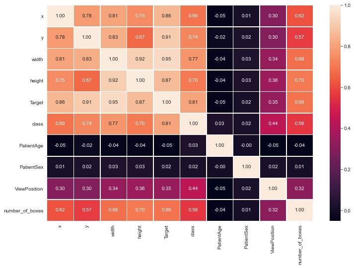

```python
plt.figure(figsize = (12,8))     #Plots a heatmap for correlation between different attributes of the dataset.
sns.heatmap(obj_df.corr(), linewidth = 0.5, fmt = '.2f', annot = True);
```

### *8.3 PAIRPLOT BETWEEN THE VARIABLES*

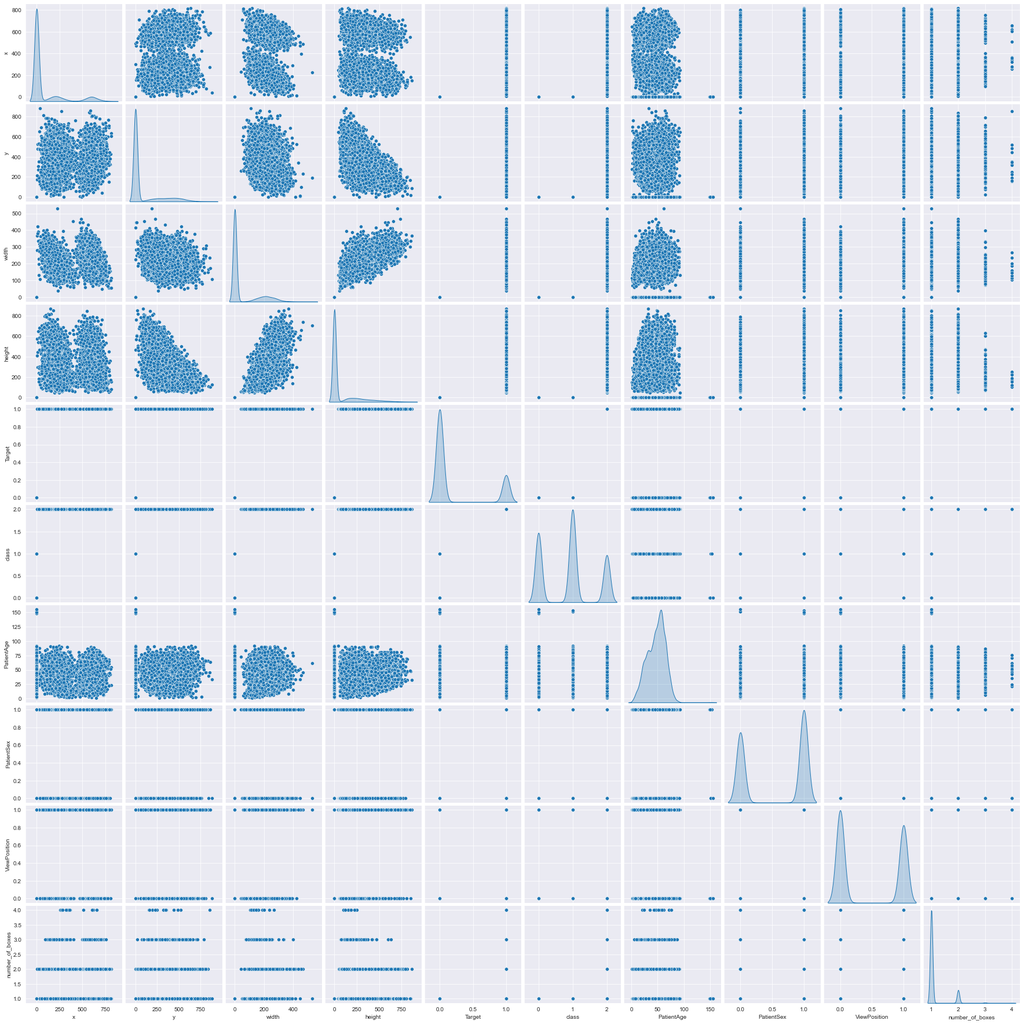

```python
sns.pairplot(obj_df, diag_kind='kde');     #Plots a pairplot of all the columns of the dataframe
```

#### **OBSERVATIONS:**

- Patient Age and Patient Sex do not show any significant correlation with any attribute.
- 'Target' and 'class' are highly correlated with 'x', 'y', 'width', and 'height'.
- 'x', 'y', 'width', and 'height' show high correlation with each other.
- View Position show moderate correlation with 'Target' and 'Class'.

### **9. SOME INTERESTING BIVARIATE AND MULTIVARIATE PLOTS**

### *9.1 'Patient Age' vs 'Target'*

#### Let's check the patient age distribution w.r.t. Target

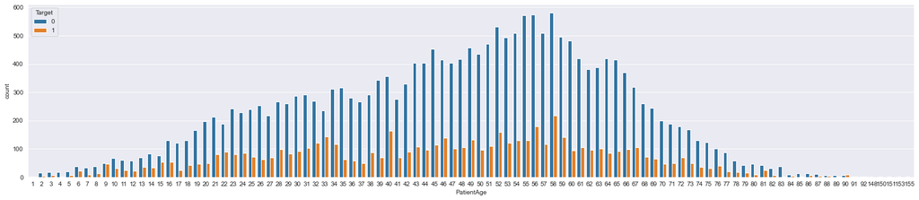

```python
plt.figure(figsize = (25, 5))
sns.countplot(x = 'PatientAge', hue = 'Target', data = df);
```

#### For sake of simplicity we may also bin the ages and once again draw the corresponding plot.

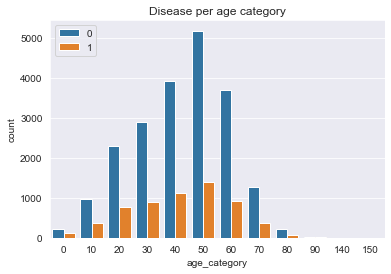

```python
df['age_category'] = (df['PatientAge'] // 10) * 10
ax = sns.countplot(x="age_category", hue="Target", data=df);
ax.set_title('Disease per age category')
ax.legend(title='Disease')
ax.legend()
```

#### *OBSERVATIONS:* These plots signify that the instances of Normal patients are much higher than the Pneumonic patients in all age groups.

### *9.2 'Class' vs 'Target'*

#### Let's plot the number of examinations for each class detected, grouped by Target value.

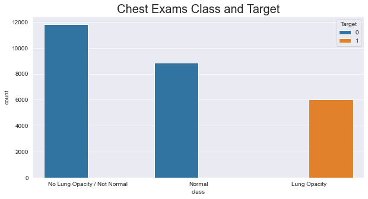

```python
plt.figure(figsize = (10,5))
sns.countplot(x = 'class', hue = 'Target', data = df)
plt.title("Chest Exams Class and Target", fontsize=20)
```

#### Lets check the distribution of 'Target' and 'Class' columns using pie charts

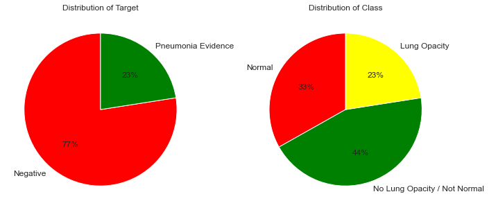

```python
fig = plt.figure(figsize = (10, 6))
ax = fig.add_subplot(121)
g = (df['Target'].value_counts()
    .plot(kind = 'pie', autopct = '%.0f%%',
          labels = ['Negative', 'Pneumonia Evidence'],
          colors = ['red', 'green'],
          startangle = 90,
          title = 'Distribution of Target', fontsize = 12)
    .set_ylabel(''))
ax = fig.add_subplot(122)
g = (df['class'].value_counts().sort_index(ascending = False)
    .plot(kind = 'pie', autopct = '%.0f%%',
          colors = ['red', 'green', 'yellow'],
          startangle = 90, title = 'Distribution of Class',
          fontsize = 12)
    .set_ylabel(''))
plt.tight_layout()
```

#### *OBSERVATIONS:*

- The 3 Classes are distributed along the dataset with approximately 1/3rd share of Normal, 44% for Not Normal / Not Opaque, and 22% for Opaque.
- However, Target shows 77% share for Negative Patients and 23% share for Pneumonia Positive Patients.

### *9.3 'Patient Sex' vs 'Target'*

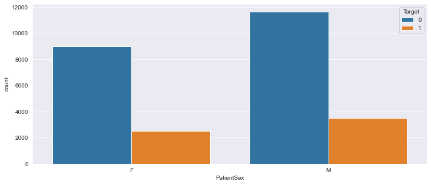

```python
plt.figure(figsize = (12,5))
sns.countplot(x = 'PatientSex', hue = 'Target', data = df);
```

#### *OBSERVATIONS:* The instances with Target=0 are more than that of Target=1 for both Males and Females.

### *9.4 'Patient Sex' vs 'Class'*

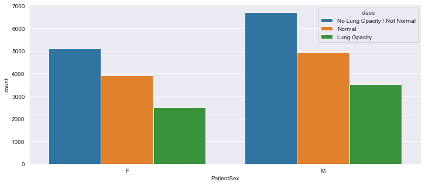

```python
plt.figure(figsize = (12,5))
sns.countplot(x = 'PatientSex', hue = 'class', data = df);
```

#### *OBSERVATIONS:* The instances of No Lung Opacity / Not Normal are the highest, followed by Normal and Lung Opacity for both Males and Females.

### *9.5 'Patient Sex' vs 'Patient Age' and 'Target'*

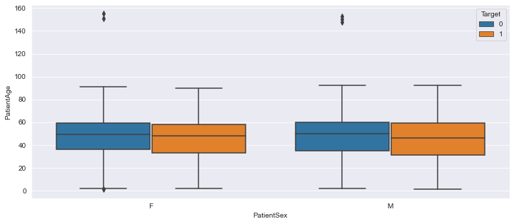

```python
plt.figure(figsize = (12,5))
sns.boxplot(x='PatientSex', y='PatientAge', hue='Target', data=df);
```

#### *OBSERVATIONS:* The above boxplots do not show any significant relation between Target with Patient Age and Sex.

### *9.6 'Patient Sex' vs 'Patient Age' and 'Class'*

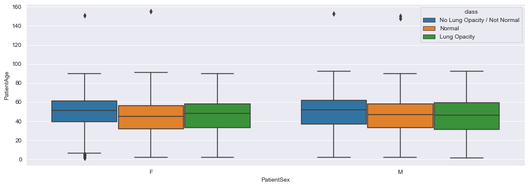

```python
plt.figure(figsize = (15,5))
sns.boxplot(x='PatientSex', y='PatientAge', hue='class', data=df);
```

#### *OBSERVATIONS:* The above boxplots do not show any significant relation between Class with Patient Age and Sex.

### *9.7 'Patient Sex' vs 'Patient Age' and 'View Position'*

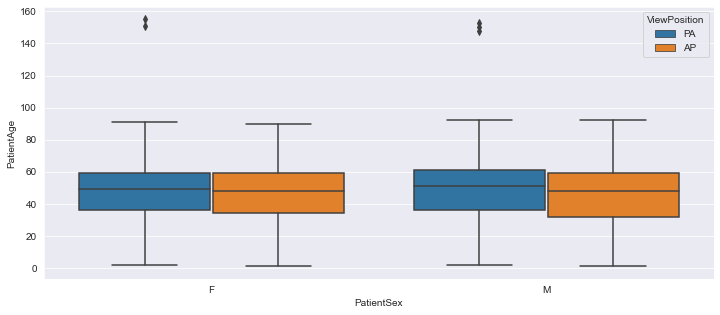

```python
plt.figure(figsize = (12,5))
sns.boxplot(x='PatientSex', y='PatientAge', hue='ViewPosition', data=df);
```

#### *OBSERVATIONS:* The above boxplots do not show any significant relation between View Position with Patient Age and Sex.

### *9.8 'View Position' vs 'Target'*

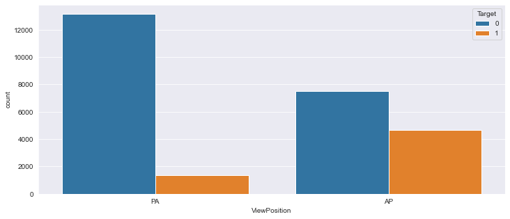

```python
plt.figure(figsize = (12,5))
sns.countplot(x = 'ViewPosition', hue = 'Target', data = df);
```

### *9.9 'View Position' vs 'Class'*

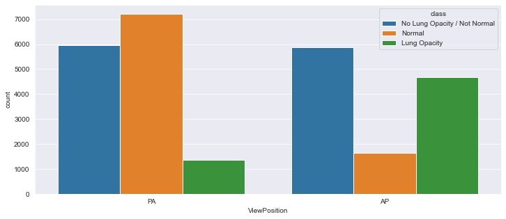

```python
plt.figure(figsize = (12,5))
sns.countplot(x = 'ViewPosition', hue = 'class', data = df);
```

#### **OBSERVATIONS:** PA Position shows most cases as Normal or No Lung Opacity / Not Normal. However, AP Position shows more cases as No Lung Opacity / Not Normal. This indicates that as far as possible, X-Ray scans must be taken in AP Position for better results.

### *9.10 'View Position' vs 'Patient Sex'*

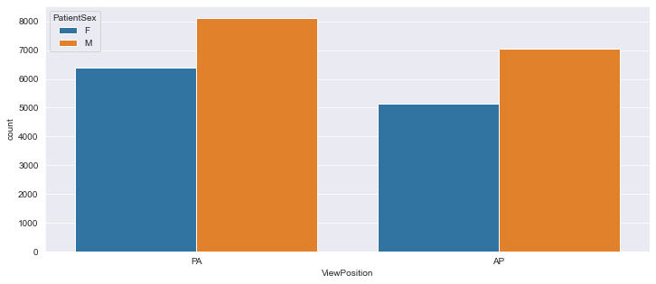

```python
plt.figure(figsize = (12,5))
sns.countplot(x = 'ViewPosition', hue = 'PatientSex', data = df);
```

#### *OBSERVATIONS:* The instances for both PA and AP Positions are show almost identical trend amongst Males and Females.

### **10. CREATING AND ANALYSING NEW FEATURE : SEVERITY SCORE**

#### Our dataset can be trained to perform the qualitative analysis of Pneumonia by classifying whether the patient (based on their X-Ray Scan) is having Pneumonia or not. Also, the model can be trained to localise the opacities and show them with the help of bounding boxes.

#### We propose to add another dimension in the dataset which could help us perform the quantitative analysis on the X-Ray Image. It can tell how severe the patient is infected with the help of a parameter called 'Severity Score'.

#### This severity score shall be directly proportional to the intensity of lungs infection and could accordingly help the physician determine the course of treatment.

#### This way the doctors would be able to clinically correlate the score with the patient's condition and decide whether the patient can be home treated or needs hospitalization. Also, unnecessary under-use or over-use of prescription drugs may be avoided and the patient can be treated in a more objective manner.

#### We propose to use the bounding box parameters, namely 'height' and 'width' to calculate the area of each box.

#### Next we shall determine the number of bounding boxes for each patient.

#### As is obvious, a more severe patient shall have larger bounding box areas, meaning larger opaque areas. Also, apart from size of the box, their numbers per X-ray image shall have a bearing on the severity.

#### Instead of using each of these parameters independently, we propose to add the areas of all the bounding boxes for a unique patient id to reach to a robust indicator of severity, which we shall call 'Severity Score'.

#### First of all we shall calculate the areas of individual bounding boxes by multiplying their width with the corresponding height. For this we shall create a dataset 'df2' by taking relevant columns from dataset 'df1'.

```python
df2 = df1[['patientId', 'width', 'height']]
df2
```

|  | patientId | width | height |
| --- | --- | --- | --- |
| 4 | 00436515-870c-4b36-a041-de91049b9ab4 | 213.0 | 379.0 |
| 5 | 00436515-870c-4b36-a041-de91049b9ab4 | 256.0 | 453.0 |
| 8 | 00704310-78a8-4b38-8475-49f4573b2dbb | 160.0 | 104.0 |
| 9 | 00704310-78a8-4b38-8475-49f4573b2dbb | 162.0 | 137.0 |
| 14 | 00aecb01-a116-45a2-956c-08d2fa55433f | 94.0 | 135.0 |
| ... | ... | ... | ... |
| 30220 | c1e73a4e-7afe-4ec5-8af6-ce8315d7a2f2 | 179.0 | 273.0 |
| 30221 | c1ec14ff-f6d7-4b38-b0cb-fe07041cbdc8 | 240.0 | 284.0 |
| 30222 | c1ec14ff-f6d7-4b38-b0cb-fe07041cbdc8 | 228.0 | 379.0 |
| 30225 | c1f7889a-9ea9-4acb-b64c-b737c929599a | 261.0 | 345.0 |
| 30226 | c1f7889a-9ea9-4acb-b64c-b737c929599a | 201.0 | 356.0 |

9555 rows × 3 columns

```python
df2['Box_Area'] = (df2['width']*df2['height'])
df2
```

|  | patientId | width | height | Box_Area |
| --- | --- | --- | --- | --- |
| 4 | 00436515-870c-4b36-a041-de91049b9ab4 | 213.0 | 379.0 | 80727.0 |
| 5 | 00436515-870c-4b36-a041-de91049b9ab4 | 256.0 | 453.0 | 115968.0 |
| 8 | 00704310-78a8-4b38-8475-49f4573b2dbb | 160.0 | 104.0 | 16640.0 |
| 9 | 00704310-78a8-4b38-8475-49f4573b2dbb | 162.0 | 137.0 | 22194.0 |
| 14 | 00aecb01-a116-45a2-956c-08d2fa55433f | 94.0 | 135.0 | 12690.0 |
| ... | ... | ... | ... | ... |
| 30220 | c1e73a4e-7afe-4ec5-8af6-ce8315d7a2f2 | 179.0 | 273.0 | 48867.0 |
| 30221 | c1ec14ff-f6d7-4b38-b0cb-fe07041cbdc8 | 240.0 | 284.0 | 68160.0 |
| 30222 | c1ec14ff-f6d7-4b38-b0cb-fe07041cbdc8 | 228.0 | 379.0 | 86412.0 |
| 30225 | c1f7889a-9ea9-4acb-b64c-b737c929599a | 261.0 | 345.0 | 90045.0 |
| 30226 | c1f7889a-9ea9-4acb-b64c-b737c929599a | 201.0 | 356.0 | 71556.0 |

9555 rows × 4 columns

#### Now we shall add the areas of all the bounding boxes corresponding to the individual patient IDs.

```python
df3=df2.groupby(['patientId']).sum().reset_index()
df3
```

|  | patientId | width | height | Box_Area |
| --- | --- | --- | --- | --- |
| 0 | 000db696-cf54-4385-b10b-6b16fbb3f985 | 316.0 | 880.0 | 139952.0 |
| 1 | 000fe35a-2649-43d4-b027-e67796d412e0 | 565.0 | 847.0 | 239669.0 |
| 2 | 001031d9-f904-4a23-b3e5-2c088acd19c6 | 749.0 | 1284.0 | 480960.0 |
| 3 | 001916b8-3d30-4935-a5d1-8eaddb1646cd | 114.0 | 206.0 | 23484.0 |
| 4 | 0022073f-cec8-42ec-ab5f-bc2314649235 | 469.0 | 1014.0 | 238266.0 |
| ... | ... | ... | ... | ... |
| 6007 | ffa424d2-6e6b-4eed-93ab-7551e8941215 | 342.0 | 433.0 | 74088.0 |
| 6008 | ffae40ab-fcfe-4311-a74a-89f605dba48b | 128.0 | 138.0 | 17664.0 |
| 6009 | ffd787b6-59ca-48cb-bd15-bcedd52cf37c | 523.0 | 940.0 | 246398.0 |
| 6010 | fff0b503-72a5-446a-843d-f3d152e39053 | 180.0 | 209.0 | 37620.0 |
| 6011 | fffb2395-8edd-4954-8a89-ffe2fd329be3 | 426.0 | 838.0 | 181134.0 |

6012 rows × 4 columns

#### We shall now calculate the Severity Score by dividing the Box Area with the maximum area so that we get the Severity Score on a scale of 0.0 to 10.0.

```python
df3['Severity_Score']=df3['Box_Area']/(np.max(df3['Box_Area']*0.1))
df3
```

|  | patientId | width | height | Box_Area | Severity_Score |
| --- | --- | --- | --- | --- | --- |
| 0 | 000db696-cf54-4385-b10b-6b16fbb3f985 | 316.0 | 880.0 | 139952.0 | 2.211309 |
| 1 | 000fe35a-2649-43d4-b027-e67796d412e0 | 565.0 | 847.0 | 239669.0 | 3.786886 |
| 2 | 001031d9-f904-4a23-b3e5-2c088acd19c6 | 749.0 | 1284.0 | 480960.0 | 7.599401 |
| 3 | 001916b8-3d30-4935-a5d1-8eaddb1646cd | 114.0 | 206.0 | 23484.0 | 0.371059 |
| 4 | 0022073f-cec8-42ec-ab5f-bc2314649235 | 469.0 | 1014.0 | 238266.0 | 3.764718 |
| ... | ... | ... | ... | ... | ... |
| 6007 | ffa424d2-6e6b-4eed-93ab-7551e8941215 | 342.0 | 433.0 | 74088.0 | 1.170626 |
| 6008 | ffae40ab-fcfe-4311-a74a-89f605dba48b | 128.0 | 138.0 | 17664.0 | 0.279100 |
| 6009 | ffd787b6-59ca-48cb-bd15-bcedd52cf37c | 523.0 | 940.0 | 246398.0 | 3.893208 |
| 6010 | fff0b503-72a5-446a-843d-f3d152e39053 | 180.0 | 209.0 | 37620.0 | 0.594414 |
| 6011 | fffb2395-8edd-4954-8a89-ffe2fd329be3 | 426.0 | 838.0 | 181134.0 | 2.862005 |

6012 rows × 5 columns

#### We shall extract the important columns of 'df3' in a new dataset 'df3_1'

```python
df3_1 = df3[['patientId', 'Severity_Score']]
df3_1
```

|  | patientId | Severity_Score |
| --- | --- | --- |
| 0 | 000db696-cf54-4385-b10b-6b16fbb3f985 | 2.211309 |
| 1 | 000fe35a-2649-43d4-b027-e67796d412e0 | 3.786886 |
| 2 | 001031d9-f904-4a23-b3e5-2c088acd19c6 | 7.599401 |
| 3 | 001916b8-3d30-4935-a5d1-8eaddb1646cd | 0.371059 |
| 4 | 0022073f-cec8-42ec-ab5f-bc2314649235 | 3.764718 |
| ... | ... | ... |
| 6007 | ffa424d2-6e6b-4eed-93ab-7551e8941215 | 1.170626 |
| 6008 | ffae40ab-fcfe-4311-a74a-89f605dba48b | 0.279100 |
| 6009 | ffd787b6-59ca-48cb-bd15-bcedd52cf37c | 3.893208 |
| 6010 | fff0b503-72a5-446a-843d-f3d152e39053 | 0.594414 |
| 6011 | fffb2395-8edd-4954-8a89-ffe2fd329be3 | 2.862005 |

6012 rows × 2 columns

#### We shall also extract unique patient instances from 'df1' to a new dataset 'df4'

```python
df4 = df1.drop_duplicates(subset = 'patientId')
df4
```

|  | patientId | x | y | width | height | Target | class | PatientAge | PatientSex | ViewPosition | number_of_boxes |
| --- | --- | --- | --- | --- | --- | --- | --- | --- | --- | --- | --- |
| 4 | 00436515-870c-4b36-a041-de91049b9ab4 | 264.0 | 152.0 | 213.0 | 379.0 | 1 | Lung Opacity | 32 | F | AP | 2 |
| 8 | 00704310-78a8-4b38-8475-49f4573b2dbb | 323.0 | 577.0 | 160.0 | 104.0 | 1 | Lung Opacity | 75 | M | PA | 2 |
| 14 | 00aecb01-a116-45a2-956c-08d2fa55433f | 288.0 | 322.0 | 94.0 | 135.0 | 1 | Lung Opacity | 6 | F | AP | 2 |
| 16 | 00c0b293-48e7-4e16-ac76-9269ba535a62 | 306.0 | 544.0 | 168.0 | 244.0 | 1 | Lung Opacity | 23 | F | AP | 2 |
| 19 | 00f08de1-517e-4652-a04f-d1dc9ee48593 | 181.0 | 184.0 | 206.0 | 506.0 | 1 | Lung Opacity | 58 | M | AP | 2 |
| ... | ... | ... | ... | ... | ... | ... | ... | ... | ... | ... | ... |
| 30208 | c18d1138-ba74-4af5-af21-bdd4d2c96bb5 | 646.0 | 386.0 | 141.0 | 206.0 | 1 | Lung Opacity | 63 | F | AP | 2 |
| 30214 | c1cddf32-b957-4753-acaa-472ab1447e86 | 269.0 | 416.0 | 193.0 | 285.0 | 1 | Lung Opacity | 49 | M | AP | 2 |
| 30219 | c1e73a4e-7afe-4ec5-8af6-ce8315d7a2f2 | 666.0 | 418.0 | 186.0 | 223.0 | 1 | Lung Opacity | 47 | F | AP | 2 |
| 30221 | c1ec14ff-f6d7-4b38-b0cb-fe07041cbdc8 | 609.0 | 464.0 | 240.0 | 284.0 | 1 | Lung Opacity | 54 | M | AP | 2 |
| 30225 | c1f7889a-9ea9-4acb-b64c-b737c929599a | 570.0 | 393.0 | 261.0 | 345.0 | 1 | Lung Opacity | 72 | F | AP | 2 |

6012 rows × 11 columns

#### We shall extract the important columns of 'df4' in a new dataset 'df4_1'

```python
df4_1 = df4[['patientId', 'PatientAge', 'PatientSex', 'ViewPosition', 'number_of_boxes']]
df4_1
```

|  | patientId | PatientAge | PatientSex | ViewPosition | number_of_boxes |
| --- | --- | --- | --- | --- | --- |
| 4 | 00436515-870c-4b36-a041-de91049b9ab4 | 32 | F | AP | 2 |
| 8 | 00704310-78a8-4b38-8475-49f4573b2dbb | 75 | M | PA | 2 |
| 14 | 00aecb01-a116-45a2-956c-08d2fa55433f | 6 | F | AP | 2 |
| 16 | 00c0b293-48e7-4e16-ac76-9269ba535a62 | 23 | F | AP | 2 |
| 19 | 00f08de1-517e-4652-a04f-d1dc9ee48593 | 58 | M | AP | 2 |
| ... | ... | ... | ... | ... | ... |
| 30208 | c18d1138-ba74-4af5-af21-bdd4d2c96bb5 | 63 | F | AP | 2 |
| 30214 | c1cddf32-b957-4753-acaa-472ab1447e86 | 49 | M | AP | 2 |
| 30219 | c1e73a4e-7afe-4ec5-8af6-ce8315d7a2f2 | 47 | F | AP | 2 |
| 30221 | c1ec14ff-f6d7-4b38-b0cb-fe07041cbdc8 | 54 | M | AP | 2 |
| 30225 | c1f7889a-9ea9-4acb-b64c-b737c929599a | 72 | F | AP | 2 |

6012 rows × 5 columns

#### And now to create the final dataset 'df5', we merge the datasets 'df3_1' and 'df4_1' based on patient IDs

```python
df5 = pd.merge(df3_1, df4_1, on='patientId', how='right')
df5
```

|  | patientId | Severity_Score | PatientAge | PatientSex | ViewPosition | number_of_boxes |
| --- | --- | --- | --- | --- | --- | --- |
| 0 | 00436515-870c-4b36-a041-de91049b9ab4 | 3.107876 | 32 | F | AP | 2 |
| 1 | 00704310-78a8-4b38-8475-49f4573b2dbb | 0.613596 | 75 | M | PA | 2 |
| 2 | 00aecb01-a116-45a2-956c-08d2fa55433f | 0.510751 | 6 | F | AP | 2 |
| 3 | 00c0b293-48e7-4e16-ac76-9269ba535a62 | 1.572085 | 23 | F | AP | 2 |
| 4 | 00f08de1-517e-4652-a04f-d1dc9ee48593 | 3.376816 | 58 | M | AP | 2 |
| ... | ... | ... | ... | ... | ... | ... |
| 6007 | c18d1138-ba74-4af5-af21-bdd4d2c96bb5 | 0.828799 | 63 | F | AP | 2 |
| 6008 | c1cddf32-b957-4753-acaa-472ab1447e86 | 1.323449 | 49 | M | AP | 2 |
| 6009 | c1e73a4e-7afe-4ec5-8af6-ce8315d7a2f2 | 1.427495 | 47 | F | AP | 2 |
| 6010 | c1ec14ff-f6d7-4b38-b0cb-fe07041cbdc8 | 2.442312 | 54 | M | AP | 2 |
| 6011 | c1f7889a-9ea9-4acb-b64c-b737c929599a | 2.553374 | 72 | F | AP | 2 |

6012 rows × 6 columns

#### We are now done with the data preparation for Severity Score and are good to go with its analysis.

### *5-point Summary of Severity Score*

```python
df5['Severity_Score'].describe()
```

```
count    6012.000000
mean        1.946772
std         1.564837
min         0.048634
25%         0.749464
50%         1.448138
75%         2.738583
max        10.000000
Name: Severity_Score, dtype: float64
```

#### *OBSERVATIONS:*

- Severity Score ranges from 0.0 to 10.0
- Here minimum value is 0.049 and maximum value is 10.0
- 75% of the total positive population have a severity score under 2.74
- Only 25% population has severity score between 2.74 and 10.0 with a mean of 1.95
- This indicates that the number of patients with high severity score is very less.

#### This can also be visualised graphically with the help of distribution and boxplots.

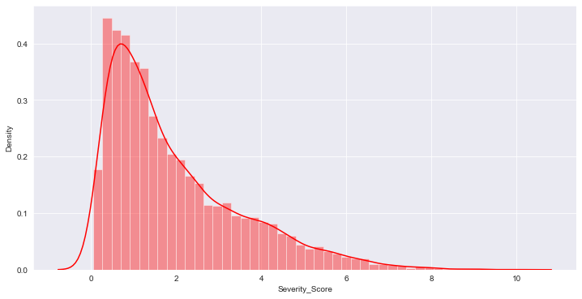

```python
plt.figure(figsize = (12,6))
sns.distplot(df5['Severity_Score'], color = 'red');
```

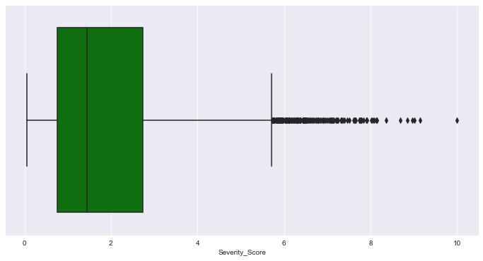

```python
plt.figure(figsize = (12,6))
sns.boxplot(df5['Severity_Score'], color = 'green');
```

#### We shall now analyze the relationship of Severity Score with Patient Sex and View Position

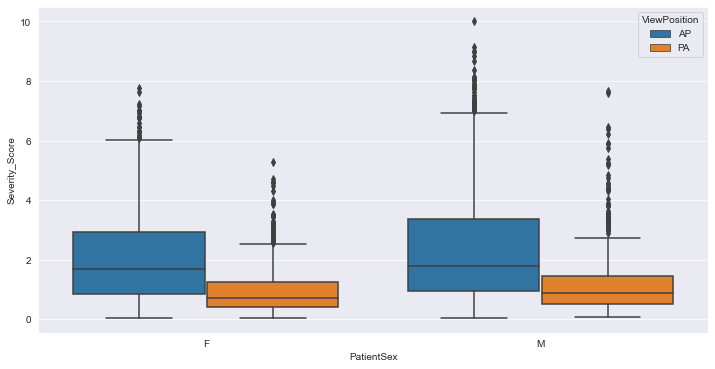

```python
plt.figure(figsize = (12,6))
sns.boxplot(x='PatientSex', y='Severity_Score', data=df5,  hue = 'ViewPosition');
```

#### This plot gives us the following insights:

- Males and females show almost similar distribution of Severity Score for lower scores.
- However, high severity scores (>8) are visible only in male population.
- AP position is more likely to give a larger share of high severity scores.
- In fact, severity scores of more than 8 are only visible in X-rays taken with AP position.

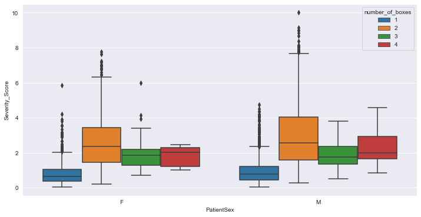

```python
plt.figure(figsize = (12,6))
sns.boxplot(x='PatientSex', y='Severity_Score', hue = 'number_of_boxes', data=df5);
```

#### This plot gives us the following insights:

- Males and females show almost similar distribution of Severity Score for lower scores.
- However, high severity scores (>8) are visible only in male population.
- Patients with just 1 bounding box in their scans tend to have the least Severity Score.
- Contrary to assumption, high Severity Scores are visible only in patients having 2 bounding boxes and not in patients having 3 or 4 boxes.
- In fact, severity scores of more than 4.0 are primarily visible in X-rays having 2 bounding boxes.

#### We shall now analyze the relationship of Severity Score with Patient Sex and Patient Age

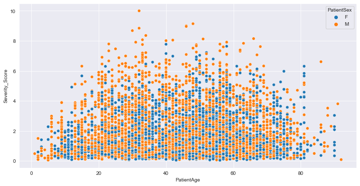

```python
plt.figure(figsize = (12,6))
sns.scatterplot(x='PatientAge', y='Severity_Score', hue='PatientSex', data=df5);
```